# Analise Exploratória da Série A do Campeonato Brasileiro de Futebol

Author

João Paulo Bonifácio

Published

July 6, 2025

# Introdução

Este seguinte trabalho tem como objetivo fazer uma analise exploratorioa usando dados sobre a Série A do Campeonato Brasileiro de Futebol. O recorte temporal escolhido é de 2014 a 2023, abrangendo 10 anos de competição e contendo 200 observaçoes e 36 variaveis. A base de dados foi retirada do site [FBREF](https://fbref.com) e contem as principais informações sobre a campanha anual dos times participantes da competição.

Os Dados foram coletados através de web scraping usando o pacote `rvest` e posteriormente tratados e organizados no software R. O site supracitado permite a extração de dados com algumas limitações. A documentação, assim como a fonte dos dados do site, podem ser acessadas no seguinte [link](https://www.sports-reference.com/bot-traffic.html).

Para o tratamento e organização dos dados, foram utilizados os pacotes presentes na coleção do `tidyverse`, principalmente o `dplyr`. Para a visualização, foram utilizados os pacotes `ggplot2` e `kableExtra`.

A analise esta dividida em em três partes. Na primeira é feito um levantamento a respeito da quantidade de cartões amarelos e vermelhos recebidos pelos times antes e após a implementação do VAR (Video Assistant Referee). Na segunda parte, é feita uma analise dos times vencedores, dos quatro melhores colocados e dos rebaixados, buscando um padrão entre eles. Na terceira se mede a correlação de algumas estatisticas presentes na base de dado escolhida.

# Cartões Amarelos e Vermelhos Antes e Após o VAR

O árbitro de vídeo (VAR) foi introduzido no Campeonato Brasileiro em 2019 com o objetivo de aumentar a precisão das decisões arbitrais e reduzir erros cruciais durante as partidas. Esta tecnologia permite que árbitros revisem lances controversos com o auxílio de câmeras e replays, podendo influenciar diretamente na aplicação de cartões amarelos e vermelhos. Vamos analisar a distribuição do acumulo por temporada de cartões amarelos e vermelhos recebidos pelos times, antes e depois da introdução do VAR.

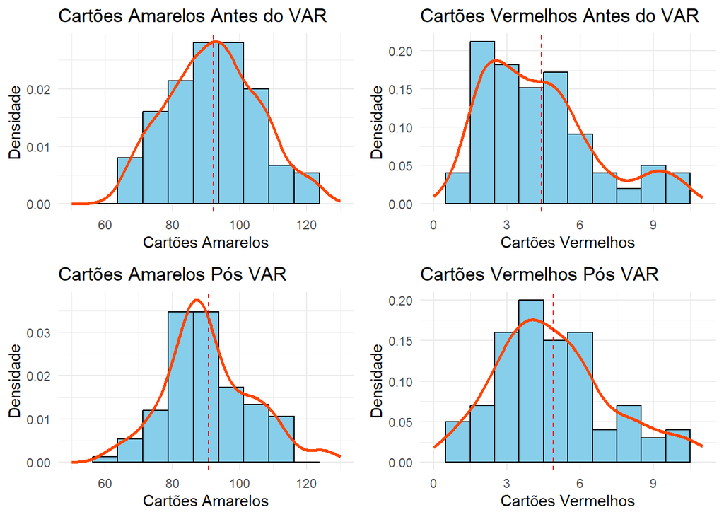

Nota-se que, em média, a quantidade de cartões, tanto amarelos quanto vermelhos, recebidos por equipe ao longo dos anos não sofreu alterações significativas após a implementação do VAR. O gráfico a seguir representa a média de cartões amarelos e vermelhos recebidos por equipe antes e após a implementação do VAR, acompanhado de seus seguintes desvios padrões.

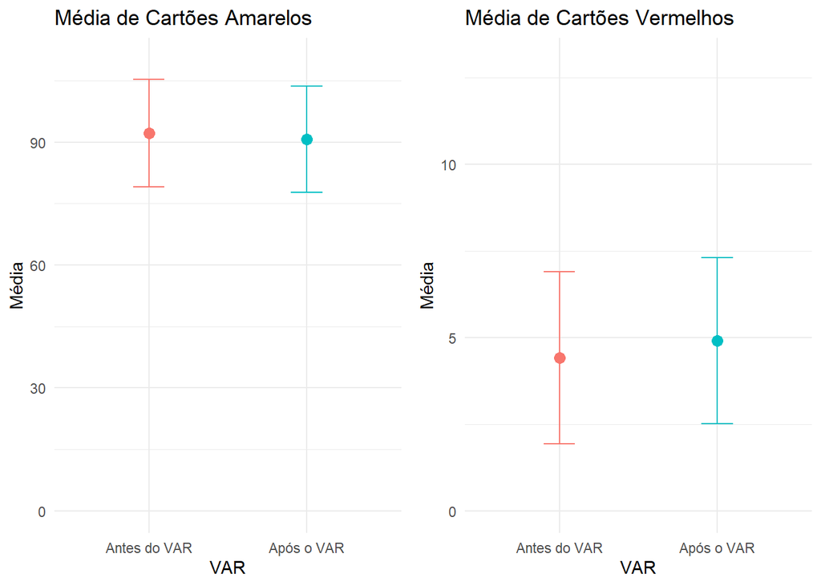

Contudo, ao observar a quantidade absoluta de cartões, percebe-se uma diminuição na quantidade de cartões amarelos e um aumento na quantidade de cartões vermelhos. A tabela abaixo apresenta a frequência de cartões amarelos e vermelhos antes e após a implementação do VAR.

| Cartões | Antes do VAR | Após o VAR | Totais |
| --- | --- | --- | --- |
| Amarelos | 9217 | 9075 | 18292 |
| Vermelhos | 442 | 491 | 933 |
| Total | 9659 | 9566 | 19225 |

A diferença apresentada pode ser explicada pelo fato de que, com a chegada do VAR, criou-se uma nova regra que permite ao juiz, após revisão, cancelar um cartão amarelo e apresentar um cartão vermelho diretamente, caso julgue necessário. Contudo, para uma análise mais aprofundada deste caso, seria necessário analisar as expulsões diretas (por cartões vermelhos) e as expulsões indiretas (por acúmulo de cartões amarelos). No entanto, essa informação só foi adicionada à base de dados a partir de 2019, o que impossibilita uma análise mais detalhada sobre o tema.

# Estatisticas dos Times Vencedores, Quatro Melhores e Rebaixados

Explorando os dados, podemos fazer alguns comparativos entre os times vencedores de cada ano, afim de buscar um padrão. Além disso, podemos comparar as estatisticas dos quatro melhores colocados (G4) e comparar com os rebaixados (Z4).

**Campeões**

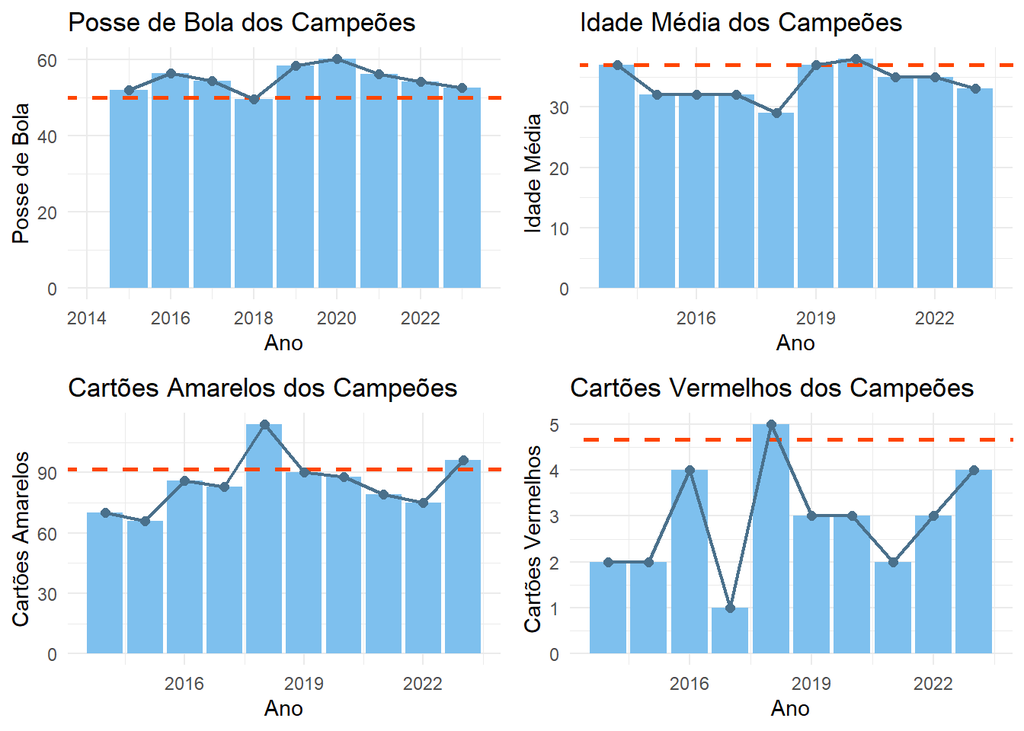

Acima, temos quatro gráficos que comparam as estatísticas dos times campeões de cada ano. O primeiro gráfico mostra a posse de bola dos campeões, o segundo mostra a idade média dos jogadores, o terceiro mostra o número de cartões amarelos recebidos e o quarto mostra o número de cartões vermelhos recebidos. Em cada gráfico, a linha tracejada laranja representa a média geral de todas as equipes ao longo dos 10 anos analisados. Chama-se atenção para o fato de que os campeões costumam ter uma posse de bola acima da média, uma idade média dos jogadores abaixo da média, um número de cartões amarelos e vermelhos recebidos abaixo da média. Isso sugere que os times campeões costumam ter um estilo de jogo mais controlado e disciplinado.

**G4**

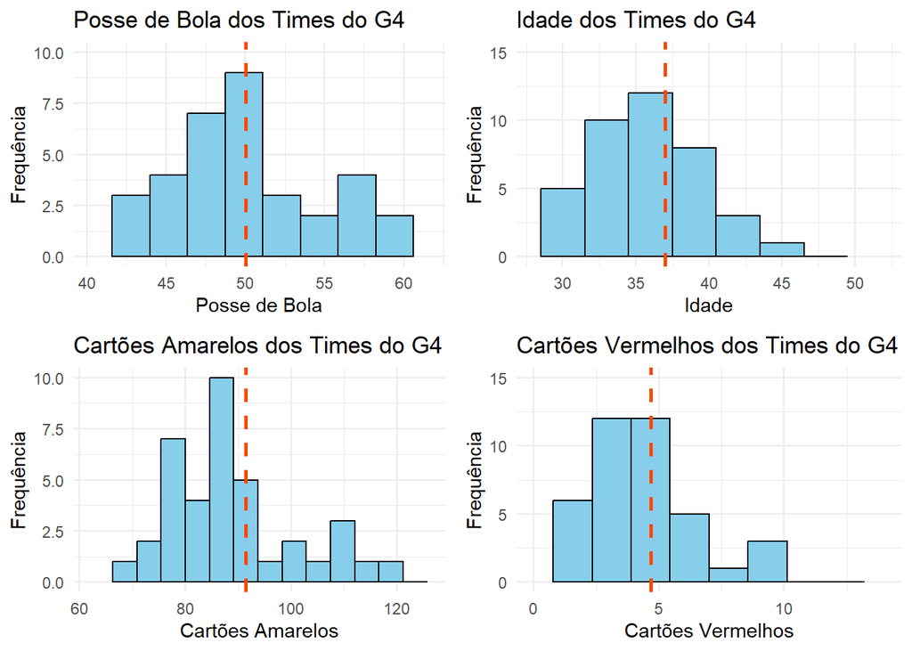

Acima, temos quatro histogramas que apresentão as estatísticas dos times que ficaram no G4 (quatro primeiros colocados) de cada ano incluindo o campeão. O primeiro histograma mostra a posse de bola dos times, o segundo mostra a idade média dos jogadores, o terceiro mostra o número de cartões amarelos recebidos e o quarto mostra o número de cartões vermelhos recebidos. Em cada histograma, a linha tracejada laranja representa a média geral de todas as equipes ao longo dos 10 anos analisados. Em todos os casos existe assimetria em relação a média geral. Chama-se a atenção para fato dos times melhores colocados, terem, em sua maioria, times mais jovens.

**Z4**

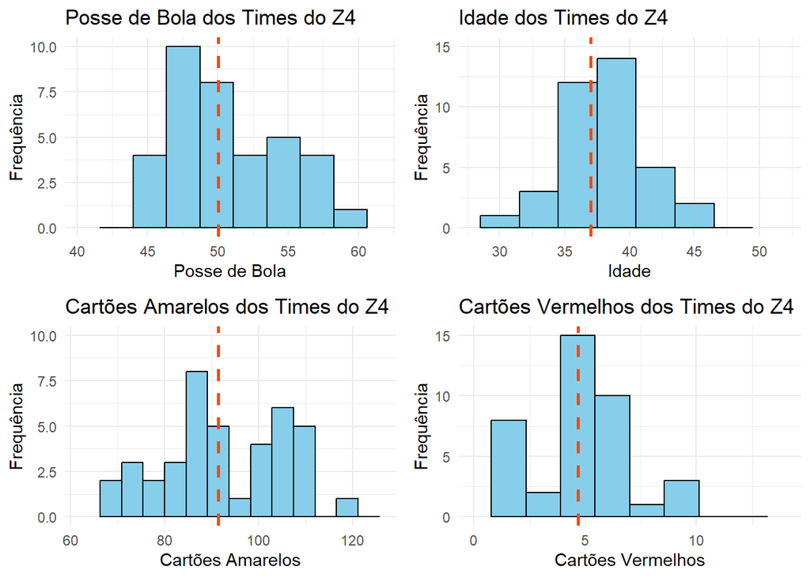

# Posse de Bola

**Gols**

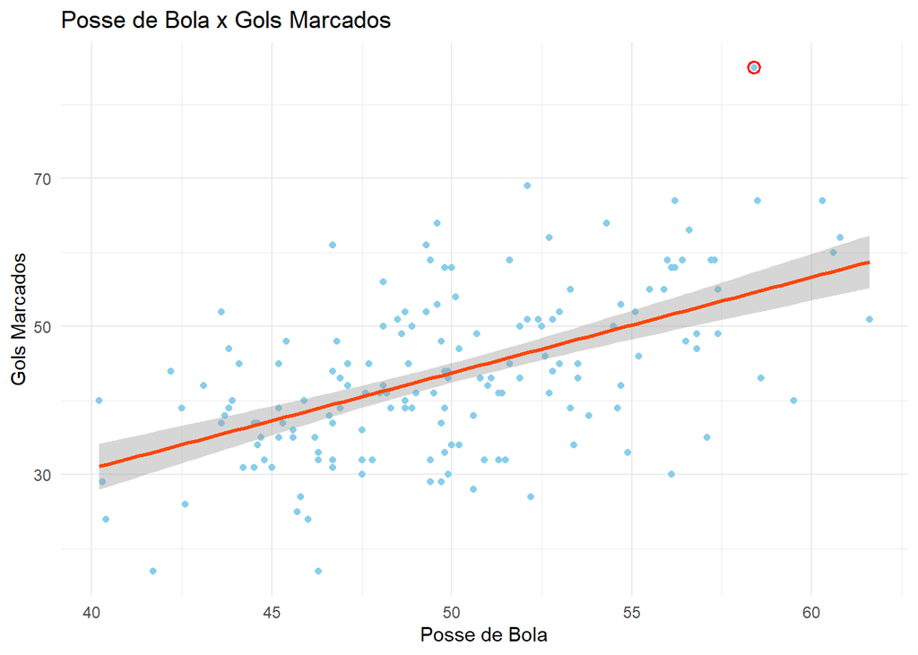

Este primeiro gráfico mostra a relação entre a posse de bola e a quantidade de gols marcados pelas equipes. Pode-se observar uma relação positiva entre as duas variáveis, indicando que equipes com maior posse de bola tendem a marcar mais gols. O *autlier* marcado em vermelho representa a campanha de 2019 do Flamengo, em que foram marcados 85 gols, o que é um valor muito acima da média.

**Assistências**

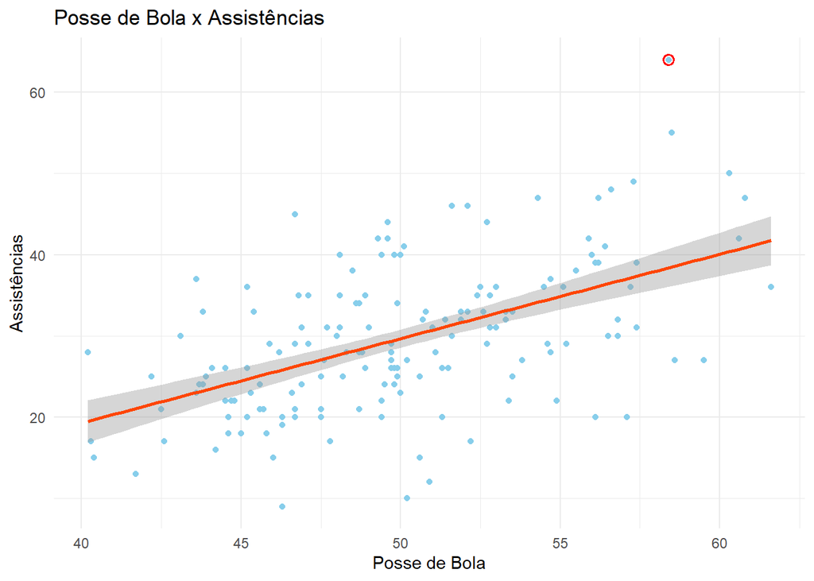

**Posição**

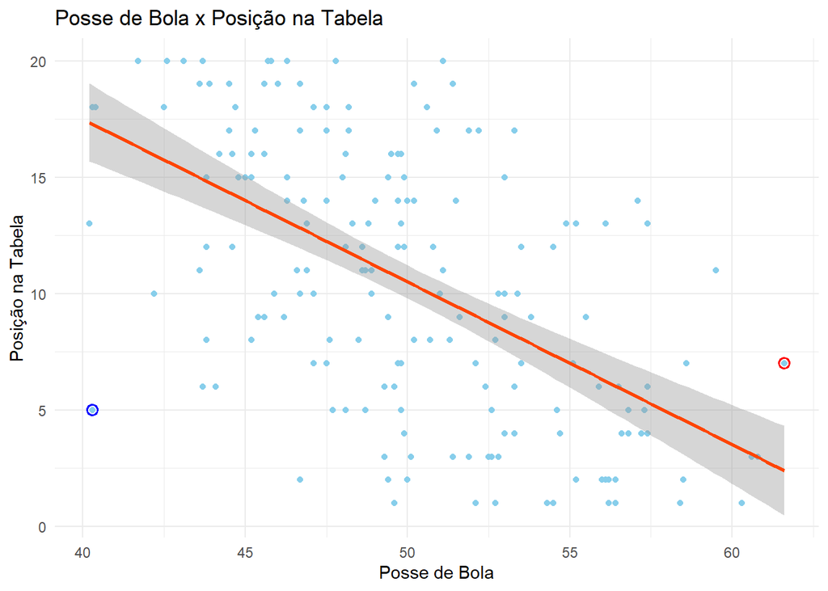

Este grafico mostra a relação entre a posse de bola e a posição relativa na tabela. Pode-se observar uma relação negativa entre as duas variáveis, indicando que equipes com maior posse de bola tendem a ocupar posições mais altas na tabela. Alem disso, neste caso, como os valores da posição so podem assumir valores interios de 1 a 20, a relação é mais clara. O valor marcado em vermelho representa a camapanha do Fluminense em 2023, evidenciando a o estilo de jogo do técnico Fernando Diniz, que prioriza a posse de bola mas sem muita objetividade. Já o valor marcado em azul representa a campanha do Botafogo(RJ) em 2018, que apesar de ter uma posse de bola baixa, conseguiu uma posição alta na tabela, destacando o trabalho do técnico José Ricardo, que é conhecido por jogar no erro do adversário, priorizando a defesa e o contra-ataque.

**Pontos**

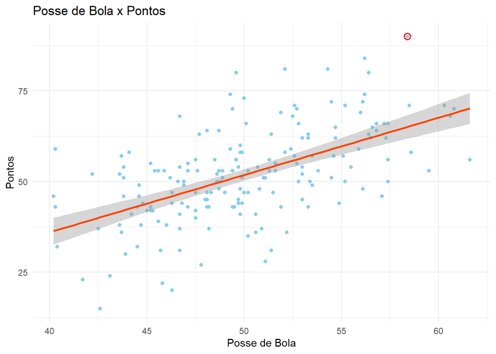

**Matriz de Correlação**

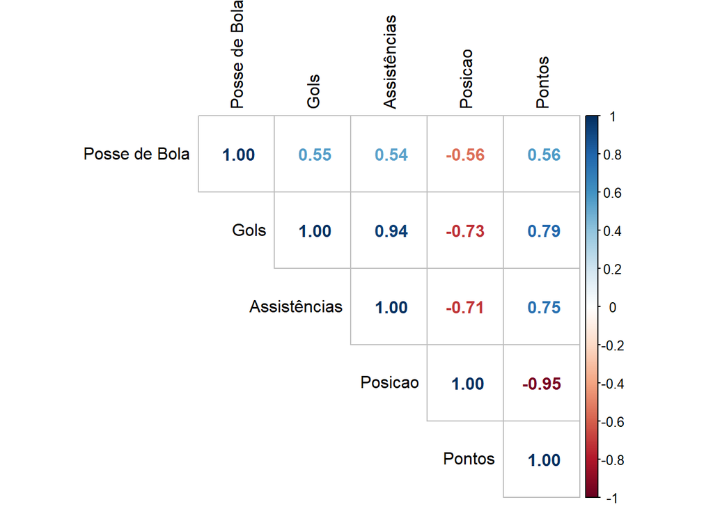

A matriz de correlação acima mostra os coeficientes de correlação de Pearson entre a posse de bola e as demais variáveis analisadas. Pode-se observar que a posse de bola tem uma correlação positiva com a quantidade de gols marcados e de assistências realizadas, e uma correlação negativa com a posição relativa na tabela. Além disso, a posse de bola tem uma correlação positiva com a quantidade de pontos conquistados pelas equipes. A matriz também mostra as correlações entre as demais variáveis onde pode-se observar que a menor correlação esta entre a posse de bola e o numero de assitências. Já a maior correlação se da pela posição na tabela e a quantidade de pontos acumulado.

# Referencias

### Bibliografia

Hadley Wickham, Garrett Grolemund. 2017. R for Data Science. http://r4ds.had.co.nz/

R Core Team (2021). R: A language and environment for statistical computing. R Foundation for Statistical Computing, Vienna, Austria. URL https://www.R-project.org/.

RStudio Team (2020). RStudio: Integrated Development for R. RStudio, PBC, Boston, MA URL http://www.rstudio.com/.

Wickham, H. (2016). ggplot2: Elegant Graphics for Data Analysis. Springer-Verlag New York. ISBN 978-3-319-24277-4, URL https://ggplot2.tidyverse.org.

Wickham, H., François, R., Henry, L., & Müller, K. (2021). dplyr: A Grammar of Data Manipulation. R package version 1.0.7. URL https://CRAN.R-project.org/package=dplyr. FBREF - Sports Reference. URL https://fbref.com/pt/

Campeonato Brasileiro de Futebol. URL https://pt.wikipedia.org/wiki/Campeonato_Brasileiro_de_Futebol